# EP09-respuesta-equipo-5

# Pregunta 6

**Usando herramientas estándares para la exploración de modelos del entorno R, buscar entre dos y cinco predictores de entre las variables seleccionadas al azar en el punto 3, para agregar al modelo de regresión lineal simple obtenido en el paso 5.**

Antes de ajustar modelos se exploran gráficamente las relaciones entre `Weight` y las ocho variables sorteadas en la Pregunta 3, y su correlación con el modelo de RLS ya construido:

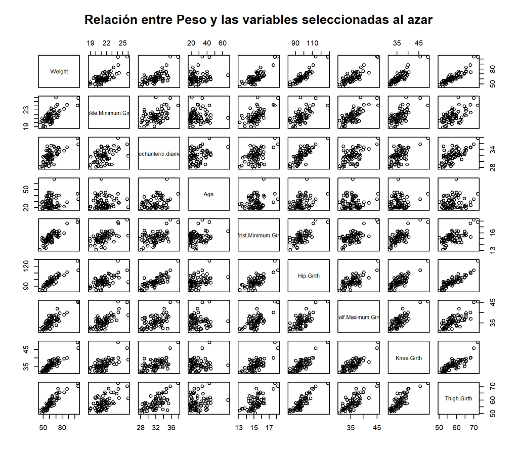

```r
pairs(casos[, c("Weight", variables_seleccionadas)],
      main = "Relación entre Peso y las variables seleccionadas al azar")
```

```r
round(cor(casos[, c("Weight", variables_seleccionadas)]), 2)
```

```
##                         Weight Ankle.Minimum.Girth Bitrochanteric.diameter  Age
## Weight                    1.00                0.71                    0.67 0.21
## Ankle.Minimum.Girth       0.71                1.00                    0.46 0.05
## Bitrochanteric.diameter   0.67                0.46                    1.00 0.31
## Age                       0.21                0.05                    0.31 1.00
## Wrist.Minimum.Girth       0.81                0.61                    0.46 0.23
## Hip.Girth                 0.91                0.60                    0.79 0.34
## Calf.Maximum.Girth        0.82                0.74                    0.59 0.05
## Knee.Girth                0.89                0.64                    0.60 0.08
## Thigh.Girth               0.90                0.58                    0.66 0.14
##                         Wrist.Minimum.Girth Hip.Girth Calf.Maximum.Girth
## Weight                                 0.81      0.91               0.82
## Ankle.Minimum.Girth                    0.61      0.60               0.74
## Bitrochanteric.diameter                0.46      0.79               0.59
## Age                                    0.23      0.34               0.05
## Wrist.Minimum.Girth                    1.00      0.70               0.65
## Hip.Girth                              0.70      1.00               0.70
## Calf.Maximum.Girth                     0.65      0.70               1.00
## Knee.Girth                             0.72      0.81               0.80
## Thigh.Girth                            0.65      0.89               0.77
##                         Knee.Girth Thigh.Girth
## Weight                        0.89        0.90
## Ankle.Minimum.Girth           0.64        0.58
## Bitrochanteric.diameter       0.60        0.66
## Age                           0.08        0.14
## Wrist.Minimum.Girth           0.72        0.65
## Hip.Girth                     0.81        0.89
## Calf.Maximum.Girth            0.80        0.77
## Knee.Girth                    1.00        0.84
## Thigh.Girth                   0.84        1.00
```

Se observa que varias de las variables (`Knee.Girth`, `Calf.Maximum.Girth`, `Hip.Girth`, `Thigh.Girth`, `Wrist.Minimum.Girth`) muestran relaciones aproximadamente lineales y una correlación considerable con `Weight`, por lo que son buenas candidatas para complementar el modelo de RLS.

```r
# Modelo con las 8 variables sorteadas en el punto 3, más la variable del modelo de RLS
mls_completo <- lm(Weight ~ Waist.Girth + Ankle.Minimum.Girth + Bitrochanteric.diameter + Age + Wrist.Minimum.Girth + Hip.Girth + Calf.Maximum.Girth + Knee.Girth + Thigh.Girth, data = casos)
summary(mls_completo)
```

```
##
## Call:
## lm(formula = Weight ~ Waist.Girth + Ankle.Minimum.Girth + Bitrochanteric.diameter +
##     Age + Wrist.Minimum.Girth + Hip.Girth + Calf.Maximum.Girth +
##     Knee.Girth + Thigh.Girth, data = casos)
##
## Residuals:
##     Min      1Q  Median      3Q     Max
## -5.1228 -1.3416  0.0253  1.1515  5.4357
##
## Coefficients:
##                          Estimate Std. Error t value Pr(>|t|)
## (Intercept)             -83.06580    6.29084 -13.204  < 2e-16 ***
## Waist.Girth               0.41087    0.07627   5.387 1.26e-06 ***
## Ankle.Minimum.Girth       0.38748    0.30327   1.278 0.206298
## Bitrochanteric.diameter   0.09264    0.23559   0.393 0.695553
## Age                      -0.02357    0.03657  -0.645 0.521600
## Wrist.Minimum.Girth       2.04806    0.50449   4.060 0.000144 ***
## Hip.Girth                 0.19935    0.13980   1.426 0.159051
## Calf.Maximum.Girth        0.57765    0.20110   2.872 0.005624 **
## Knee.Girth                0.57933    0.21089   2.747 0.007926 **
## Thigh.Girth               0.24584    0.15749   1.561 0.123776
## ---
## Signif. codes:  0 '***' 0.001 '**' 0.01 '*' 0.05 '.' 0.1 ' ' 1
##
## Residual standard error: 2.283 on 60 degrees of freedom
## Multiple R-squared:  0.9618, Adjusted R-squared:  0.9561
## F-statistic: 167.8 on 9 and 60 DF,  p-value: < 2.2e-16
```

Para la selección de predictores se utiliza búsqueda escalonada hacia adelante (forward stepwise), con la función `step()`, partiendo de `mls` (el modelo de RLS) y evaluando incorporar, de a una, las variables del modelo `mls_completo`. El criterio usado es el AIC (a menor AIC, mejor el modelo, comparando los modelos entre sí sobre los mismos datos y variable de respuesta). Como el enunciado exige agregar **entre 2 y 5 predictores**, se limita explícitamente la búsqueda a un máximo de 5 pasos con el argumento `steps = 5`, en vez de dejar que `step()` siga agregando variables mientras el AIC siga bajando (lo que podría entregar un modelo con más de 5 predictores agregados e incumplir la restricción del enunciado):

```r
mls_step <- step(mls,
                  scope = list(lower = mls, upper = mls_completo),
                  direction = "forward",
                  steps = 5)
```

```
## Start:  AIC=217.16
## Weight ~ Waist.Girth
##
##                           Df Sum of Sq     RSS    AIC
## + Knee.Girth               1    811.74  659.17 162.97
## + Calf.Maximum.Girth       1    800.41  670.50 164.17
## + Thigh.Girth              1    543.51  927.40 186.87
## + Wrist.Minimum.Girth      1    478.87  992.04 191.59
## + Hip.Girth                1    465.87 1005.04 192.50
## + Ankle.Minimum.Girth      1    407.43 1063.48 196.46
## + Bitrochanteric.diameter  1    208.41 1262.51 208.47
## <none>                                 1470.91 217.16
## + Age                      1     39.64 1431.27 217.25
##
## Step:  AIC=162.97
## Weight ~ Waist.Girth + Knee.Girth
##
##                           Df Sum of Sq    RSS    AIC
## + Calf.Maximum.Girth       1   177.082 482.09 143.07
## + Wrist.Minimum.Girth      1   129.862 529.31 149.62
## + Ankle.Minimum.Girth      1   100.116 559.05 153.44
## + Hip.Girth                1    79.853 579.31 155.94
## + Thigh.Girth              1    70.749 588.42 157.03
## + Bitrochanteric.diameter  1    46.354 612.81 159.87
## <none>                                 659.17 162.97
## + Age                      1     0.056 659.11 164.97
##
## Step:  AIC=143.07
## Weight ~ Waist.Girth + Knee.Girth + Calf.Maximum.Girth
##
##                           Df Sum of Sq    RSS    AIC
## + Wrist.Minimum.Girth      1    91.632 390.45 130.32
## + Hip.Girth                1    59.150 422.94 135.91
## + Thigh.Girth              1    23.955 458.13 141.51
## + Ankle.Minimum.Girth      1    17.510 464.58 142.48
## + Bitrochanteric.diameter  1    17.418 464.67 142.50
## <none>                                 482.09 143.07
## + Age                      1     1.609 480.48 144.84
##
## Step:  AIC=130.32
```

[output cut: 9 more lines]

```
##
## Step:  AIC=122.22
## Weight ~ Waist.Girth + Knee.Girth + Calf.Maximum.Girth + Wrist.Minimum.Girth +
##     Hip.Girth
##
##                           Df Sum of Sq    RSS    AIC
## + Thigh.Girth              1   12.9999 325.02 121.48
## <none>                                 338.02 122.22
## + Age                      1    7.1237 330.90 122.73
## + Ankle.Minimum.Girth      1    6.4251 331.60 122.88
## + Bitrochanteric.diameter  1    0.0347 337.99 124.22
##
## Step:  AIC=121.48
## Weight ~ Waist.Girth + Knee.Girth + Calf.Maximum.Girth + Wrist.Minimum.Girth +
##     Hip.Girth + Thigh.Girth
```

```r
formula(mls_step)
```

```
## Weight ~ Waist.Girth + Knee.Girth + Calf.Maximum.Girth + Wrist.Minimum.Girth +
##     Hip.Girth + Thigh.Girth
```

La búsqueda agrega, en orden, `Knee.Girth`, `Calf.Maximum.Girth`, `Wrist.Minimum.Girth`, `Hip.Girth` y `Thigh.Girth` (5 predictores agregados al modelo de RLS, tal como exige el enunciado), bajando el AIC de 217,2 a 121,5. Por lo tanto el modelo final de RLM queda con 6 predictores en total:

```r
mls_final <- lm(Weight ~ Waist.Girth + Knee.Girth + Calf.Maximum.Girth + Wrist.Minimum.Girth + Hip.Girth + Thigh.Girth, data = casos)
summary(mls_final)
```

```
##
## Call:
## lm(formula = Weight ~ Waist.Girth + Knee.Girth + Calf.Maximum.Girth +
##     Wrist.Minimum.Girth + Hip.Girth + Thigh.Girth, data = casos)
##
## Residuals:
##     Min      1Q  Median      3Q     Max
## -5.2728 -1.3907  0.0362  0.9871  5.6521
##
## Coefficients:
##                      Estimate Std. Error t value Pr(>|t|)
## (Intercept)         -79.54275    5.47384 -14.531  < 2e-16 ***
## Waist.Girth           0.40919    0.07242   5.650 4.13e-07 ***
## Knee.Girth            0.60552    0.20443   2.962  0.00431 **
## Calf.Maximum.Girth    0.72096    0.17127   4.210 8.27e-05 ***
## Wrist.Minimum.Girth   2.08371    0.48578   4.289 6.28e-05 ***
## Hip.Girth             0.21247    0.09919   2.142  0.03606 *
## Thigh.Girth           0.23463    0.14781   1.587  0.11743
## ---
## Signif. codes:  0 '***' 0.001 '**' 0.01 '*' 0.05 '.' 0.1 ' ' 1
##
## Residual standard error: 2.271 on 63 degrees of freedom
## Multiple R-squared:  0.9603, Adjusted R-squared:  0.9565
## F-statistic: 253.8 on 6 and 63 DF,  p-value: < 2.2e-16
```

El modelo de RLM explica cerca del 96% de la varianza del peso (R² ajustado ≈ 0,957), una mejora clara respecto al 82% del modelo de RLS. `Thigh.Girth` no resulta individualmente significativo al 5% (p ≈ 0,12), pero se mantiene porque su incorporación es la que arroja el menor AIC dentro del límite de 5 predictores agregados que impone el enunciado; el criterio de selección utilizado (AIC) prioriza la capacidad predictiva conjunta del modelo por sobre la significancia individual de cada coeficiente.

# Pregunta 7

**Evaluar la bondad de ajuste (incluyendo el análisis de casos atípicos y casos influyentes) y la generalidad (condiciones para RLM) de los modelos y “arreglarlos” en caso de que presenten algún problema.**

## Bondad de ajuste: casos atípicos e influyentes

### Modelo de RLS (mls)

```r
cat("R² ajustado:", round(summary(mls)$adj.r.squared, 3), "\n\n")
```

```
## R² ajustado: 0.818
```

```r
cat("Casos atípicos (outlierTest):\n")
```

```
## Casos atípicos (outlierTest):
```

```r
print(car::outlierTest(mls))
```

```
## No Studentized residuals with Bonferroni p < 0.05
## Largest |rstudent|:
##    rstudent unadjusted p-value Bonferroni p
## 45 2.863276          0.0055919      0.39144
```

```r
cat("\nResiduos estandarizados fuera de [-3, 3]:", sum(abs(rstandard(mls)) > 3), "\n")
```

```
##
## Residuos estandarizados fuera de [-3, 3]: 0
```

```r
cat("Mayor distancia de Cook:", round(max(cooks.distance(mls)), 3))
```

```
## Mayor distancia de Cook: 0.626
```

```r
cat("R² ajustado:", round(summary(mls_final)$adj.r.squared, 3), "\n\n")
```

```
## R² ajustado: 0.956
```

```r
cat("Casos atípicos (outlierTest):\n")
```

```
## Casos atípicos (outlierTest):
```

```r
print(car::outlierTest(mls_final))
```

```
## No Studentized residuals with Bonferroni p < 0.05
## Largest |rstudent|:
##    rstudent unadjusted p-value Bonferroni p
## 61  2.71408           0.008595      0.60165
```

```r
cat("\nResiduos estandarizados fuera de [-3, 3]:", sum(abs(rstandard(mls_final)) > 3), "\n")
```

```
##
## Residuos estandarizados fuera de [-3, 3]: 0
```

```r
cat("Mayor distancia de Cook:", round(max(cooks.distance(mls_final)), 3))
```

```
## Mayor distancia de Cook: 0.52
```

```r
k <- length(coef(mls_final)) - 1
umbral_leverage <- 2 * (k + 1) / nrow(casos)
cat("Casos con apalancamiento (leverage) alto (> 2(k+1)/n =", round(umbral_leverage, 3), "):",
    sum(hatvalues(mls_final) > umbral_leverage), "\n")
```

```
## Casos con apalancamiento (leverage) alto (> 2(k+1)/n = 0.2 ): 2
```

En ambos modelos, `outlierTest()` no detecta casos atípicos estadísticamente significativos (p de Bonferroni > 0,05), ningún residuo estandarizado supera ±3 y la distancia de Cook máxima está muy por debajo de 1. En el modelo de RLM hay 2 casos con apalancamiento algo más alto que el resto, pero como su distancia de Cook no es alta, no llegan a ser casos influyentes que distorsionen el modelo. En consecuencia, ambos modelos presentan una buena bondad de ajuste y no requieren eliminar observaciones.

## Generalidad: condiciones para RLS y RLM

```r
cat("Normalidad de los residuos (Shapiro-Wilk):\n")
```

```
## Normalidad de los residuos (Shapiro-Wilk):
```

```r
print(shapiro.test(resid(mls)))
```

```
##
##  Shapiro-Wilk normality test
##
## data:  resid(mls)
## W = 0.99471, p-value = 0.9926
```

```r
cat(" Homocedasticidad (ncvTest):\n")
```

```
##  Homocedasticidad (ncvTest):
```

```r
print(car::ncvTest(mls))
```

```
## Non-constant Variance Score Test
## Variance formula: ~ fitted.values
## Chisquare = 16.62122, Df = 1, p = 4.5638e-05
```

```r
cat(" Independencia de los residuos (Durbin-Watson):\n")
```

```
##  Independencia de los residuos (Durbin-Watson):
```

```r
print(car::durbinWatsonTest(mls))
```

```
##  lag Autocorrelation D-W Statistic p-value
##    1     -0.07904288        2.1246   0.602
##  Alternative hypothesis: rho != 0
```

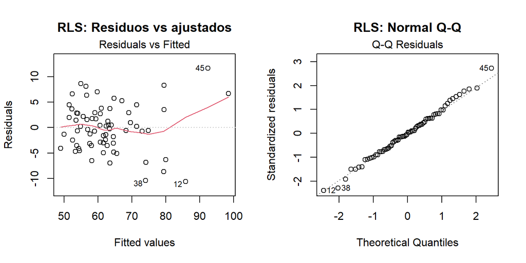

```r
par(mfrow = c(1, 2))
plot(mls, which = 1, main = "RLS: Residuos vs ajustados")
plot(mls, which = 2, main = "RLS: Normal Q-Q")
```

```r
par(mfrow = c(1, 1))
```

Para el modelo de RLS, la prueba de Shapiro-Wilk (p ≈ 0,99) y el gráfico Q-Q no muestran problemas de normalidad, y la prueba de Durbin-Watson (p ≈ 0,61) no evidencia autocorrelación entre los residuos. Sin embargo, la prueba de homocedasticidad (`ncvTest`) resulta significativa (p < 0,001): la varianza de los residuos no es constante, aumentando junto con los valores predichos. Esto es una condición que **no se cumple** para el modelo de RLS. Como no fue posible corregirla dentro del alcance de este ejercicio, se deja como un riesgo explícito: los coeficientes estimados siguen siendo válidos, pero los errores estándar, y por lo tanto los valores p e intervalos de confianza asociados al modelo de RLS, deben interpretarse con cautela porque podrían estar subestimados.

```r
cat(" Normalidad de los residuos (Shapiro-Wilk):\n")
```

```
##  Normalidad de los residuos (Shapiro-Wilk):
```

```r
print(shapiro.test(resid(mls_final)))
```

```
##
##  Shapiro-Wilk normality test
##
## data:  resid(mls_final)
## W = 0.97734, p-value = 0.2346
```

```r
cat("\n Homocedasticidad (ncvTest):\n")
```

```
##
##  Homocedasticidad (ncvTest):
```

```r
print(car::ncvTest(mls_final))
```

```
## Non-constant Variance Score Test
## Variance formula: ~ fitted.values
## Chisquare = 2.23616, Df = 1, p = 0.13482
```

```r
cat("\n Independencia de los residuos (Durbin-Watson):\n")
```

```
##
##  Independencia de los residuos (Durbin-Watson):
```

```r
print(car::durbinWatsonTest(mls_final))
```

```
##  lag Autocorrelation D-W Statistic p-value
##    1       0.2544345      1.489515   0.036
##  Alternative hypothesis: rho != 0
```

```r
cat("\n Multicolinealidad (VIF):\n")
```

```
##
##  Multicolinealidad (VIF):
```

```r
print(car::vif(mls_final))
```

```
##         Waist.Girth          Knee.Girth  Calf.Maximum.Girth Wrist.Minimum.Girth
##            5.128720            4.948215            3.198780            2.539041
##           Hip.Girth         Thigh.Girth
##            7.467211            6.786666
```

```r
cat("\n Cantidad de datos: observaciones por predictor =",
    round(nrow(casos) / k, 2))
```

```
##
##  Cantidad de datos: observaciones por predictor = 11.67
```

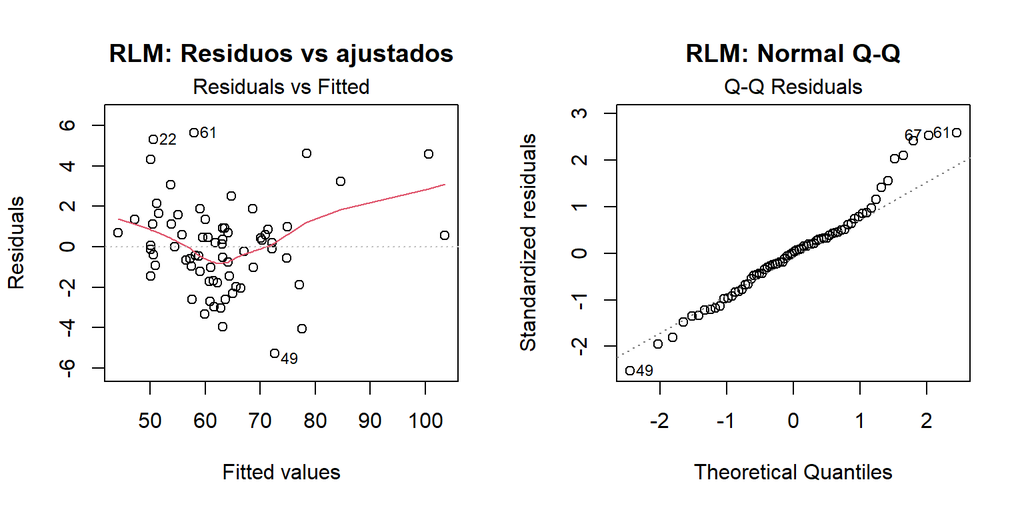

```r
par(mfrow = c(1, 2))
plot(mls_final, which = 1, main = "RLM: Residuos vs ajustados")
plot(mls_final, which = 2, main = "RLM: Normal Q-Q")
```

```r
par(mfrow = c(1, 1))
```

Para el modelo de RLM, la normalidad de los residuos (Shapiro-Wilk, p ≈ 0,23) y la homocedasticidad (`ncvTest`, p ≈ 0,13) se cumplen sin problemas. Los VIF están entre 2,5 y 7,5: no hay ningún valor sobre 10 (el umbral habitual de multicolinealidad severa), pero `Hip.Girth` y `Thigh.Girth` muestran valores moderadamente altos (> 5), esperable considerando que son medidas corporales correlacionadas entre sí; esto se deja registrado como un riesgo moderado, ya que puede hacer menos estables los coeficientes individuales, aunque no invalida las predicciones del modelo en su conjunto. La prueba de Durbin-Watson (p ≈ 0,03) sí resulta significativa, sugiriendo una leve autocorrelación positiva entre los residuos; el estadístico (≈1,49) no está lejos de 2, por lo que se interpreta como una violación leve más que severa, pero de todas formas queda como un riesgo a considerar al generalizar el modelo. Finalmente, la razón de observaciones por predictor (≈11,7) cumple con el mínimo recomendado.

En síntesis, el modelo de RLM cumple razonablemente bien las condiciones de generalidad, con dos advertencias leves (independencia y multicolinealidad moderada) que no ameritan descartarlo, mientras que el modelo de RLS presenta un problema más claro de heterocedasticidad que debe mencionarse como riesgo al utilizarlo.

# Pregunta 8

**Evaluar el poder predictivo del modelo con los datos no utilizados para construirlo.**

```r
# Predicciones y métricas de error para ambos modelos sobre los 30 casos no vistos
predicciones_rls <- predict(mls, newdata = no_vistos)
residuos_rls <- no_vistos$Weight - predicciones_rls
RMSE_rls <- sqrt(mean(residuos_rls^2))
MAE_rls  <- mean(abs(residuos_rls))
R2_pred_rls <- cor(predicciones_rls, no_vistos$Weight)^2

predicciones_rlm <- predict(mls_final, newdata = no_vistos)
residuos_rlm <- no_vistos$Weight - predicciones_rlm
RMSE_rlm <- sqrt(mean(residuos_rlm^2))
MAE_rlm  <- mean(abs(residuos_rlm))
R2_pred_rlm <- cor(predicciones_rlm, no_vistos$Weight)^2

comparacion <- data.frame(
  Modelo = c("RLS (mls)", "RLM (mls_final)"),
  R2_ajustado_entrenamiento = c(summary(mls)$adj.r.squared, summary(mls_final)$adj.r.squared),
  R2_predictivo_no_vistos = c(R2_pred_rls, R2_pred_rlm),
  RMSE_no_vistos = c(RMSE_rls, RMSE_rlm),
  MAE_no_vistos = c(MAE_rls, MAE_rlm)
)
knitr::kable(comparacion, digits = 3, caption = "Comparación de desempeño predictivo en datos no vistos")
```

Comparación de desempeño predictivo en datos no vistos

| Modelo | R2_ajustado_entrenamiento | R2_predictivo_no_vistos | RMSE_no_vistos | MAE_no_vistos |
| --- | --- | --- | --- | --- |
| RLS (mls) | 0.818 | 0.624 | 5.708 | 4.304 |
| RLM (mls_final) | 0.956 | 0.882 | 3.086 | 2.428 |

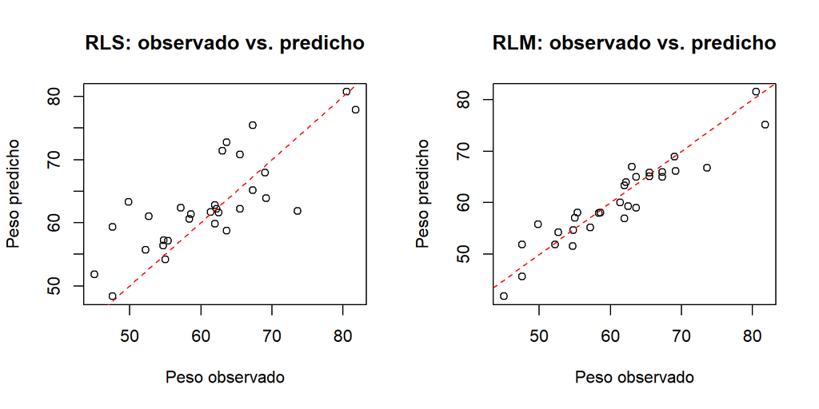

```r
par(mfrow = c(1, 2))
plot(no_vistos$Weight, predicciones_rls,
     xlab = "Peso observado", ylab = "Peso predicho",
     main = "RLS: observado vs. predicho")
abline(a = 0, b = 1, col = "red", lty = 2)

plot(no_vistos$Weight, predicciones_rlm,
     xlab = "Peso observado", ylab = "Peso predicho",
     main = "RLM: observado vs. predicho")
abline(a = 0, b = 1, col = "red", lty = 2)
```

```r
par(mfrow = c(1, 1))
```

El modelo de RLM predice notoriamente mejor los datos no vistos que el de RLS: su error (RMSE ≈ 3,1 kg, MAE ≈ 2,4 kg) es aproximadamente la mitad del error del modelo de RLS (RMSE ≈ 5,7 kg, MAE ≈ 4,3 kg), y su R² predictivo (≈ 0,88) es más cercano a su R² ajustado de entrenamiento (≈ 0,96) que en el caso del modelo de RLS (R² predictivo ≈ 0,62 frente a un R² ajustado de entrenamiento ≈ 0,82). Esto indica que el modelo de RLM no solo ajusta mejor los datos de entrenamiento, sino que también generaliza mejor a datos nuevos.

# Conclusión

A partir de una muestra de 100 mujeres del estudio de Heinz et al. (2003), separada en 70 casos de entrenamiento y 30 de evaluación, se construyó un modelo de RLS que predice el peso a partir de la circunferencia de cintura (`Waist.Girth`), explicando cerca de un 82% de su variabilidad, y un modelo de RLM que agrega `Knee.Girth`, `Calf.Maximum.Girth`, `Wrist.Minimum.Girth`, `Hip.Girth` y `Thigh.Girth` mediante selección escalonada por AIC, explicando cerca de un 96% de la variabilidad. El modelo de RLM cumple las condiciones de bondad de ajuste y generalidad, con solo dos advertencias leves (una posible autocorrelación débil de los residuos y una multicolinealidad moderada entre algunas circunferencias corporales), mientras que el modelo de RLS presenta heterocedasticidad, lo que resta algo de confiabilidad a sus valores p e intervalos de confianza. Al evaluarlos sobre los 30 casos no vistos, el modelo de RLM predice con considerablemente menos error que el de RLS y generaliza mejor.En conclusión, agregar predictores seleccionados por su relación con el peso (circunferencias de rodilla, pantorrilla, muñeca, cadera y muslo) a un modelo simple basado solo en la circunferencia de cintura mejora sustancialmente tanto el ajuste como la capacidad predictiva del modelo, por lo que el modelo de RLM es el recomendado para predecir el peso en mujeres con características similares a las de esta muestra. Dado que la muestra es específica (solo mujeres, n=70 de entrenamiento) y que persisten algunas advertencias leves en las condiciones del modelo, sus conclusiones deben generalizarse con cautela a poblaciones distintas a la estudiada.